# MA 575: HW2

Benjamin Draves

September 19, 2017

### Exercise 3.1

We first reconstruct the model proposed in the problem.

```r
#read in data
dat = read.table("~/Desktop/Fall 2017/MA 575/book_data/airfares.txt", header = TRUE)

#take a peak
head(dat)
```

```
##   City Fare Distance
## 1    1  360     1463
## 2    2  360     1448
## 3    3  207      681
## 4    4  111      270
## 5    5   93      190
## 6    6  141      393
```

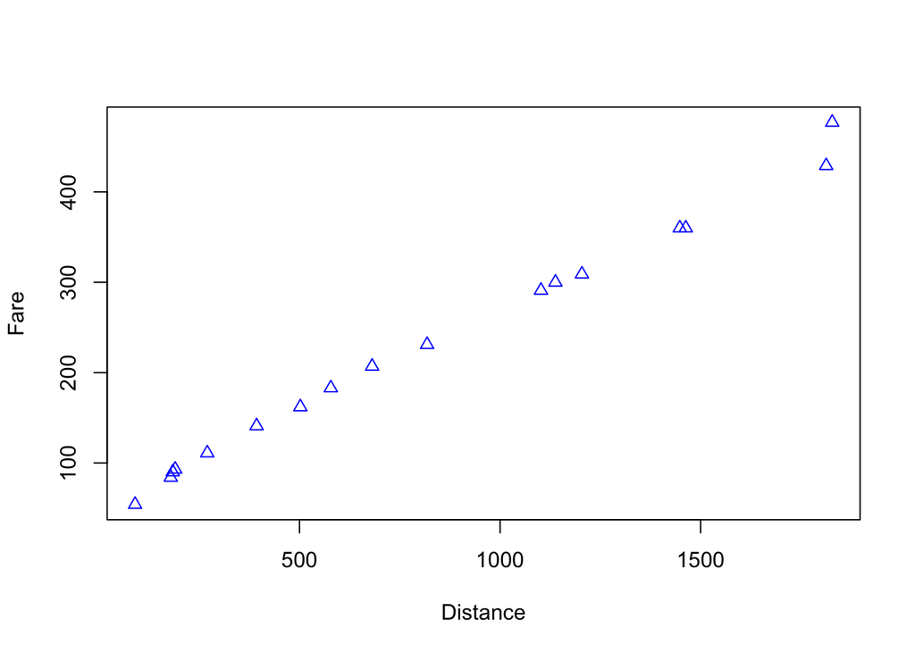

```r
#plot bivariate relationship
plot(dat$Distance, dat$Fare, ylab = "Fare", xlab = "Distance", pch = 2, col = "blue")
```

```r
#build regression model
model = lm(Fare~Distance, data = dat)

#check out summary statistics
summary(model)
```

```
##
## Call:
## lm(formula = Fare ~ Distance, data = dat)
##
## Residuals:
##     Min      1Q  Median      3Q     Max
## -18.265  -4.475   1.024   2.745  26.440
##
## Coefficients:
##              Estimate Std. Error t value Pr(>|t|)
## (Intercept) 48.971770   4.405493   11.12 1.22e-08 ***
## Distance     0.219687   0.004421   49.69  < 2e-16 ***
## ---
## Signif. codes:  0 '***' 0.001 '**' 0.01 '*' 0.05 '.' 0.1 ' ' 1
##
## Residual standard error: 10.41 on 15 degrees of freedom
## Multiple R-squared:  0.994,  Adjusted R-squared:  0.9936
## F-statistic:  2469 on 1 and 15 DF,  p-value: < 2.2e-16
```

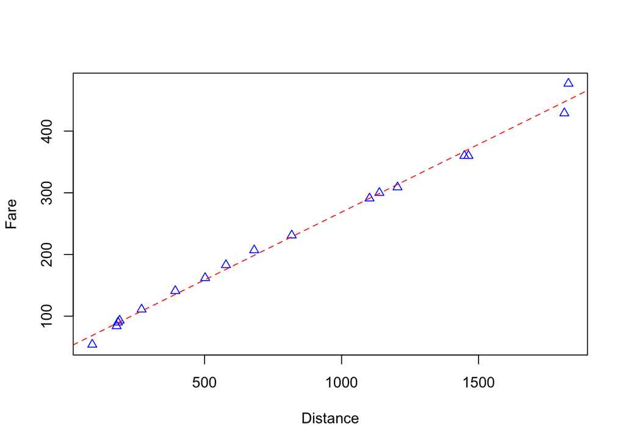

```r
#Check out the fit
plot(dat$Distance, dat$Fare, ylab = "Fare", xlab = "Distance", pch = 2, col = "blue")
abline(model, lty = 2, col = "red")
```

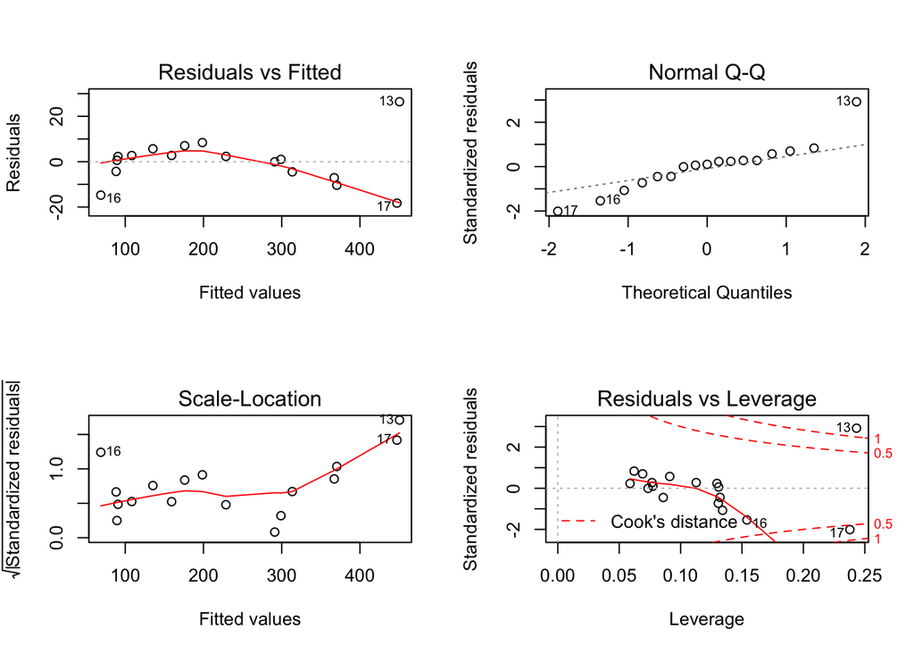

```r
#take a look at R's built in residual plots
par(mfrow = c(2,2))
plot(model)
```

#### a)

The business analyst claims that the relationship is strongly signficant. We cannot make this claim, because this model violates our assumption that we have nonconstant variance. The residual plot clearly indicates that as distance increases, so does our variance. Hence, any hypothesis testing on $\widehat{\beta}_1$ cannot be reliable. The model, however, shows that a *linear* relationship between *Distance* and *Fare* explains 99.4% of the variance. The residuals have a quadratic behavior, so more variance is likely explained by a model containing a quadratic component. This model clearly does not allow us to properly infer the strength of the relationship between these two variables. Moreover, our confidence statements about predictions rely on constant variance of the residuls which we do not have here.

#### b)

Here, we see the residuals demostrate a quadratic behavior (with the expection of one high leverage point). There is clearly two leverage points in this model, corresponding to point 13 and point 17. Both have large leverage as we see in the sesiduals vs leverage point. 17 appears to follow the quadratic relationship of the other data point, so if we added this quadratic term in the model, 17 could be a “good” leverage point. 13 is clearly a bad leverage point, with or without the quadratic fit. I would revist this point to see if there was something that made it different than the other X-values (e.g. international destination). Thus, the linear model assumption is probably not best for this data. Instead a quadtractic model should be fit to the data, with possible adding a dummy variable for international vs. domestic flights.

### Exercise 3.2

The statement is *true*. As we showed in class, if we believe the true underlying model is a quadratic model, then $\hat{e}_i \approx \beta_2x_i^2 + e_i$. Notice that this assumption does not rely on the distribution of $Y$. Hence if the $\hat{e}_i$ show some quadratic behavior, adding in a quadratic term may help fit the true model.

Notice, in some cases, however, that adding in this term may mend the behavir of the residuals. In some cases, transforming $Y$ via $g(Y)$ and then modeling $E(g(Y)|X)$ may be prove to more accuratly relate the covariate $X$ with $Y$. In either case, consideration of adding a $x^2$ term should be considered.

### Exercise 3.4

First we will reconstruct the models found in both examples.

```r
#read in data
dat = read.table("~/Desktop/Fall 2017/MA 575/book_data/glakes.txt", header = TRUE)

#take a peak
head(dat)
```

```
##   Case Tonnage Time
## 1    1    2213   17
## 2    2    3256   30
## 3    3   12203   68
## 4    4    7021   64
## 5    5     529   11
## 6    6    3192   55
```

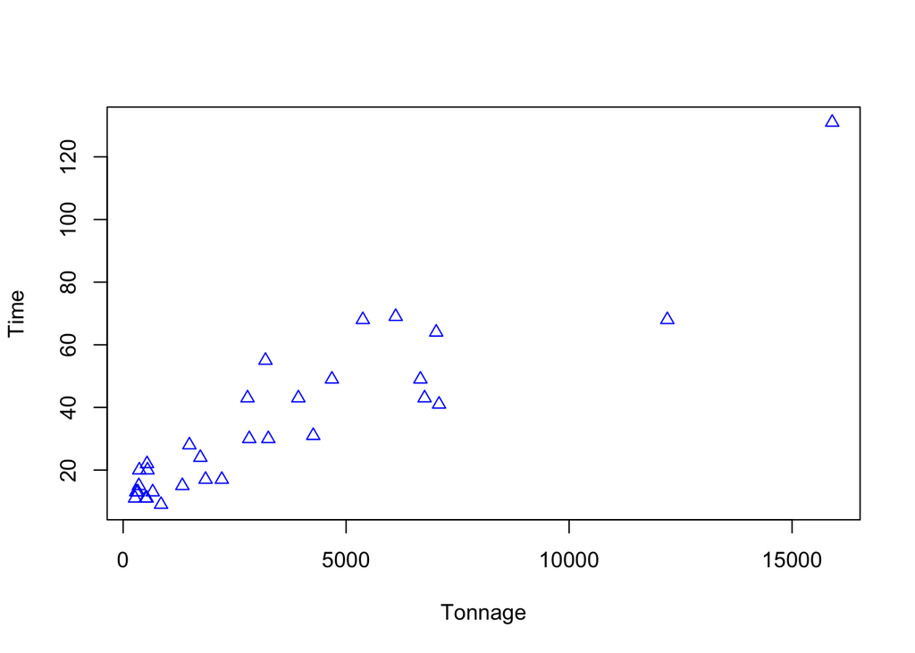

```r
#plot bivariate relationship
plot(dat$Tonnage, dat$Time, ylab = "Time", xlab = "Tonnage", pch = 2, col = "blue")
```

```r
#build regression model
model = lm(Time~Tonnage, data = dat)

#check out summary statistics
summary(model)
```

```
##
## Call:
## lm(formula = Time ~ Tonnage, data = dat)
##
## Residuals:
##     Min      1Q  Median      3Q     Max
## -23.882  -6.397  -1.261   5.931  21.850
##
## Coefficients:
##              Estimate Std. Error t value Pr(>|t|)
## (Intercept) 12.344707   2.642633   4.671 6.32e-05 ***
## Tonnage      0.006518   0.000531  12.275 5.22e-13 ***
## ---
## Signif. codes:  0 '***' 0.001 '**' 0.01 '*' 0.05 '.' 0.1 ' ' 1
##
## Residual standard error: 10.7 on 29 degrees of freedom
## Multiple R-squared:  0.8386, Adjusted R-squared:  0.833
## F-statistic: 150.7 on 1 and 29 DF,  p-value: 5.218e-13
```

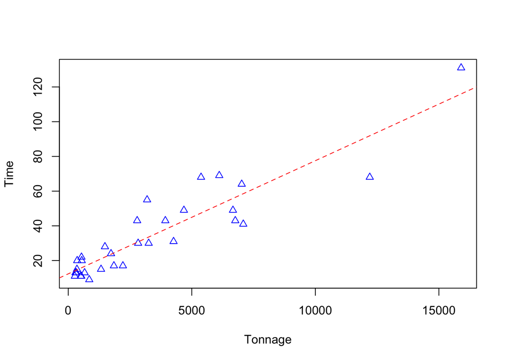

```r
#Check out the fit
plot(dat$Tonnage, dat$Time, ylab = "Time", xlab = "Tonnage", pch = 2, col = "blue")
abline(model, lty = 2, col = "red")
```

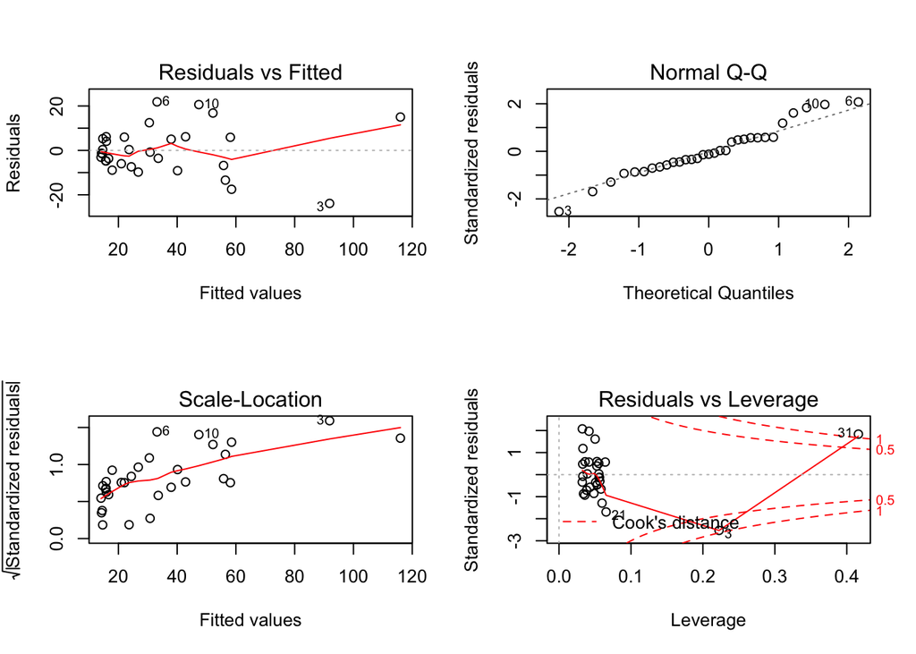

```r
#take a look at R's built in residual plots
par(mfrow = c(2,2))
plot(model)
```

#### a)

While the data does roughly follow a linear trend, we see that the regression model’s assumptions are violated. That is as *Tonnage* increases so does the variance. Moreover, there are two very high leverage points both with very high influence. So while a linear model is probably the correct choice, some adjustments need to be made to make this model valid.

#### b)

Recall we constructed our prediction intervals off the assumption that there was constance variance. But in this case, as *Tonnage* increases, so does the variance. Since the prediction interval will assume constant variance, there is no way for the interval to accomodate the growing variance for *Tonnage* $=10,000$. For this reason, we expect the interavl will be too short.

To test this arguement, we can plot the prediction intervals as follows

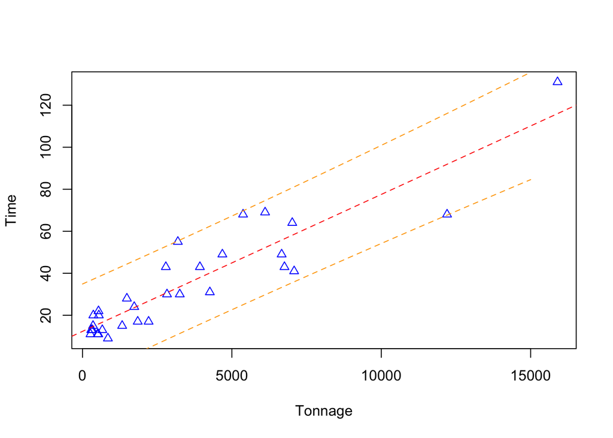

```r
#Check out the fit
plot(dat$Tonnage, dat$Time, ylab = "Time", xlab = "Tonnage", pch = 2, col = "blue")
abline(model, lty = 2, col = "red")

pred = predict(model, newdata = data.frame(Tonnage = seq(0,15000, 1000)), interval = "predict")

lines(seq(0,15000, 1000), pred[,2], col="orange", lty=2)
lines(seq(0,15000, 1000), pred[,3], col="orange", lty=2)
```

Notice as *Tonnage* increases, the observed values begin to inch closer to the prediction intervals, depecited by the orange lines. This corresponds to the prediction interval not taking into account the increasing variance.

#### c)

We now fit the second model in this problem.

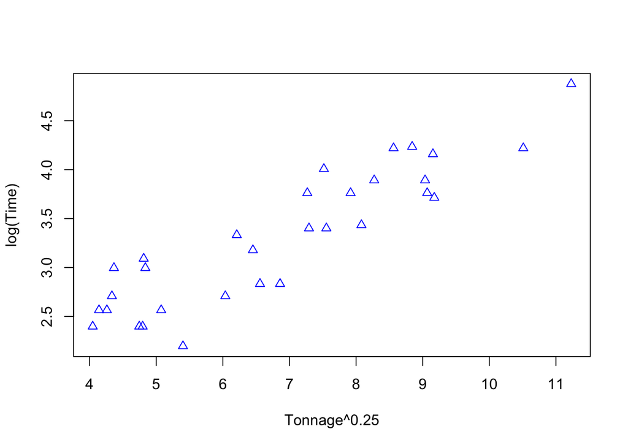

```r
#plot bivariate relationship
plot(dat$Tonnage^(0.25), log(dat$Time), ylab = "log(Time)", xlab = "Tonnage^0.25", pch = 2, col = "blue")
```

```r
#add fourth root variable
dat$Tonnage2 = dat$Tonnage^(1/4)

#build regression model
model = lm(log(Time)~Tonnage2, data = dat)

#check out summary statistics
summary(model)
```

```
##
## Call:
## lm(formula = log(Time) ~ Tonnage2, data = dat)
##
## Residuals:
##     Min      1Q  Median      3Q     Max
## -0.6607 -0.2410 -0.0044  0.2203  0.4956
##
## Coefficients:
##             Estimate Std. Error t value Pr(>|t|)
## (Intercept)  1.18842    0.19468   6.105  1.2e-06 ***
## Tonnage2     0.30910    0.02728  11.332  3.6e-12 ***
## ---
## Signif. codes:  0 '***' 0.001 '**' 0.01 '*' 0.05 '.' 0.1 ' ' 1
##
## Residual standard error: 0.3034 on 29 degrees of freedom
## Multiple R-squared:  0.8158, Adjusted R-squared:  0.8094
## F-statistic: 128.4 on 1 and 29 DF,  p-value: 3.599e-12
```

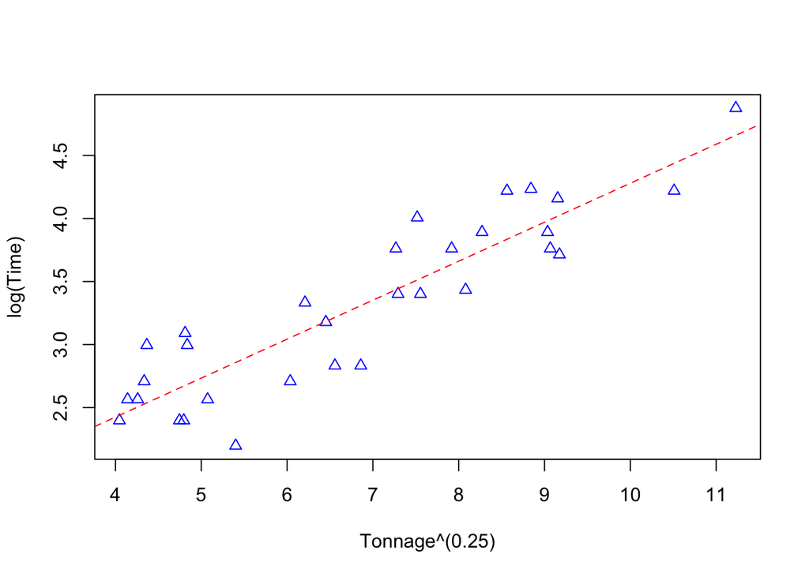

```r
#Check out the fit
plot(dat$Tonnage^(0.25), log(dat$Time), ylab = "log(Time)", xlab = "Tonnage^(0.25)", pch = 2, col = "blue")
abline(model, lty = 2, col = "red")
```

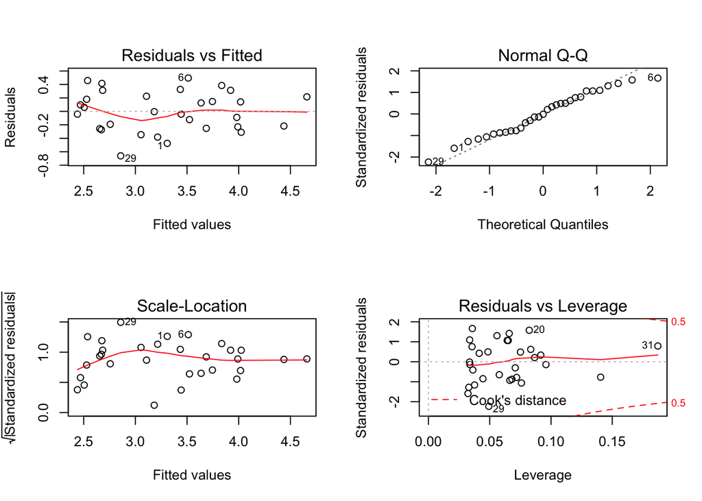

```r
#take a look at R's built in residual plots
par(mfrow = c(2,2))
plot(model)
```

There appears to be a large improvement for this model over the previous model. Our residuals show that the model has (relatively) constance variance and the trend is linear. Moreover, the leverage points in this model are “good” leverage points since they follow the trend suggested by the rest of the data. Since we have these features, the prediction intervals will be valid for time.

#### d)

There could be some normality issues with the *Tonnage* variable towards the tail (see Normal Q-Q plot). This could be fine tuned by chaning the power transformation of $X$. I would not recommend this, however, due to possible overfitting.